# Pemodelan Peubah Lag

Karimatu Ain

2023-09-12

## Impor Data

```r
data<- rio::import("https://raw.githubusercontent.com/karimatuain/mpdw/main/Data/Data%20MPDW%202.csv")
str(data)
```

```
## 'data.frame':    41 obs. of  5 variables:
##  $ Year               : int  1980 1981 1982 1983 1984 1985 1986 1987 1988 1989 ...
##  $ Price(Dollars/Unit): num  542 548 528 424 398 338 356 358 378 713 ...
##  $ Production         : int  3918 4860 6326 5042 5286 5336 4908 5006 4094 7615 ...
##  $ HarvestedAcres     : int  1660 1725 1610 1640 1672 1501 1465 1458 1216 1812 ...
##  $ Yield(Unit/Acre)   : num  2.36 2.82 3.93 3.07 3.16 3.55 3.35 3.43 3.37 4.2 ...
```

```r
data
```

```
##    Year Price(Dollars/Unit) Production HarvestedAcres Yield(Unit/Acre)
## 1  1980              542.00       3918           1660             2.36
## 2  1981              548.00       4860           1725             2.82
## 3  1982              528.00       6326           1610             3.93
## 4  1983              424.00       5042           1640             3.07
## 5  1984              398.00       5286           1672             3.16
## 6  1985              338.00       5336           1501             3.55
## 7  1986              356.00       4908           1465             3.35
## 8  1987              358.00       5006           1458             3.43
## 9  1988              378.00       4094           1216             3.37
## 10 1989              713.00       7615           1812             4.20
## 11 1990              880.00       3435           1628             2.11
## 12 1991              867.00       4938           1286             3.84
## 13 1992              890.00       5028           1531             3.28
## 14 1993              854.00       4248           1572             2.70
```

[output cut: 27 more lines]

```r
Yt<-data$Production
Xt<-data$HarvestedAcres
data_lag<-data.frame(Yt,Xt)
data_lag
```

```
##       Yt   Xt
## 1   3918 1660
## 2   4860 1725
## 3   6326 1610
## 4   5042 1640
## 5   5286 1672
## 6   5336 1501
## 7   4908 1465
## 8   5006 1458
## 9   4094 1216
## 10  7615 1812
## 11  3435 1628
## 12  4938 1286
## 13  5028 1531
## 14  4248 1572
```

[output cut: 27 more lines]

## Pembagian Data

```r
#SPLIT DATA
train<-data_lag[1:34,]
test<-data_lag[35:41,]
```

```r
#data time series
train.ts<-ts(train)
test.ts<-ts(test)
datalag.ts<-ts(data_lag)
```

## Model Koyck

Model Koyck didasarkan pada asumsi bahwa semakin jauh jarak lag peubah independen dari periode sekarang maka semakin kecil pengaruh peubah lag terhadap peubah dependen.

Koyck mengusulkan suatu metode untuk menduga model dinamis distributed lag dengan mengasumsikan bahwa semua koefisien $\beta$ mempunyai tanda sama.

Model koyck merupakan jenis paling umum dari model infinite distributed lag dan juga dikenal sebagai geometric lag

$$y_t=a(1-\lambda)+\beta_0X_t+\beta_1Z_t+\lambda
Y_{t-1}+V_t$$

dengan
$$V_t=u_t-\lambda
u_{t-1}$$

### Pemodelan

Pemodelan model Koyck dengan `R` dapat menggunakan `dLagM::koyckDlm()` . Fungsi umum dari `koyckDlm` adalah sebagai berikut.

```r
koyckDlm(x , y , intercept)
```

Fungsi `koyckDlm()` akan menerapkan model lag terdistribusi dengan transformasi Koyck satu prediktor. Nilai `x` dan `y` tidak perlu sebagai objek *time series* (`ts`). `intercept` dapat dibuat `TRUE` untuk memasukkan intersep ke dalam model.

```r
#MODEL KOYCK
model.koyck <- koyckDlm(x = train$Xt, y = train$Yt)
summary(model.koyck)
```

```
##
## Call:
## "Y ~ (Intercept) + Y.1 + X.t"
##
## Residuals:
##      Min       1Q   Median       3Q      Max
## -4006.37  -688.21    99.38   790.49  5070.81
##
## Coefficients:
##               Estimate Std. Error t value Pr(>|t|)
## (Intercept) -2212.7349  2154.1020  -1.027   0.3125
## Y.1             0.3465     0.2326   1.490   0.1466
## X.t             3.4392     1.5507   2.218   0.0343 *
## ---
## Signif. codes:  0 '***' 0.001 '**' 0.01 '*' 0.05 '.' 0.1 ' ' 1
##
## Residual standard error: 2071 on 30 degrees of freedom
## Multiple R-Squared: 0.5593,  Adjusted R-squared: 0.5299
## Wald test: 16.36 on 2 and 30 DF,  p-value: 1.568e-05
##
## Diagnostic tests:
## NULL
##
##                              alpha     beta      phi
## Geometric coefficients:  -3386.229 3.439247 0.346549
```

```r
AIC(model.koyck)
```

```
## [1] 602.4785
```

```r
BIC(model.koyck)
```

```
## [1] 608.4645
```

Dari hasil tersebut, didapat bahwa peubah $x_t$ memiliki nilai $P-Value<0.1$. Hal ini menunjukkan bahwa peubah $x_t$ berpengaruh signifikan terhadap $y$. Adapun model keseluruhannya adalah sebagai berikut

$$\hat{Y_t}= -2212.7349 +
3.4392X_t+0.3465Y_{t-1}$$
### Peramalan dan Akurasi

Berikut adalah hasil peramalan y untuk 7 periode kedepan menggunakan model koyck

```r
fore.koyck <- forecast(model = model.koyck, x=test$Xt, h=7)
fore.koyck
```

```
## $forecasts
## [1] 11758.991 10116.524 10338.355  9692.989 12805.407 13884.013 11300.050
##
## $call
## forecast.koyckDlm(model = model.koyck, x = test$Xt, h = 7)
##
## attr(,"class")
## [1] "forecast.koyckDlm" "dLagM"
```

```r
#akurasi data testing
mape.koyck <- MAPE(fore.koyck$forecasts, test$Yt)
mape.koyck
```

```
## [1] 0.1687454
```

```r
#akurasi data training
GoF(model.koyck)
```

```
##              n      MAE         MPE      MAPE     sMAPE      MASE     MSE
## model.koyck 33 1412.075 -0.07036482 0.2292465 0.2042326 0.7517537 3900531
##                 MRAE     GMRAE
## model.koyck 6.477119 0.6360112
```

```r
data.frame("MAPE test" = mape.koyck, "MAPE train" = GoF(model.koyck)$MAPE)
```

```
##   MAPE.test MAPE.train
## 1 0.1687454  0.2292465
```

## Regression with Distributed Lag

Pemodelan model Regression with Distributed Lag dengan `R` dapat menggunakan `dLagM::dlm()` . Fungsi umum dari `dlm` adalah sebagai berikut.

```r
dlm(formula , data , x , y , q , remove )
```

Fungsi `dlm()` akan menerapkan model lag terdistribusi dengan satu atau lebih prediktor. Nilai `x` dan `y` tidak perlu sebagai objek *time series* (`ts`). $q$ adalah integer yang mewakili panjang *lag* yang terbatas.

### *Lag* Optimum

```r
#penentuan lag optimum
finiteDLMauto(formula = Yt ~ Xt,
              data = data.frame(train),
              model.type = "dlm", error.type = "AIC", trace = FALSE)
```

```
##    q - k    MASE     AIC      BIC   GMRAE    MBRAE R.Adj.Sq Ljung-Box
## 10    10 0.54278 444.728 460.0428 0.52383 -0.02545  0.59632 0.5531337
```

Berdasarkan output tersebut, lag optimum didapatkan ketika lag=10. Selanjutnya dilakukan pemodelan untuk lag=10

```r
#model dlm dengan lag optimum
model.dlm <- dlm(x = train$Xt,y = train$Yt , q = 10)
summary(model.dlm)
```

```
##
## Call:
## lm(formula = model.formula, data = design)
##
## Residuals:
##     Min      1Q  Median      3Q     Max
## -2540.0 -1323.6   210.9   626.9  3794.0
##
## Coefficients:
##               Estimate Std. Error t value Pr(>|t|)
## (Intercept) -7466.1067  2620.3405  -2.849   0.0146 *
## x.t             1.5184     1.6125   0.942   0.3649
## x.1             0.5598     1.7920   0.312   0.7601
## x.2            -0.4264     1.7133  -0.249   0.8077
## x.3             1.8417     1.8483   0.996   0.3387
## x.4            -0.2104     1.7964  -0.117   0.9087
## x.5             1.8407     1.7560   1.048   0.3152
## x.6            -3.4627     1.8848  -1.837   0.0911 .
## x.7             2.5745     2.0952   1.229   0.2427
## x.8            -0.5317     1.9320  -0.275   0.7879
## x.9             4.1516     2.0206   2.055   0.0624 .
## x.10           -0.2123     1.8334  -0.116   0.9097
## ---
## Signif. codes:  0 '***' 0.001 '**' 0.01 '*' 0.05 '.' 0.1 ' ' 1
##
## Residual standard error: 2103 on 12 degrees of freedom
## Multiple R-squared:  0.7894, Adjusted R-squared:  0.5963
## F-statistic: 4.089 on 11 and 12 DF,  p-value: 0.01134
##
## AIC and BIC values for the model:
##       AIC      BIC
## 1 444.728 460.0427
```

```r
AIC(model.dlm)
```

```
## [1] 444.728
```

```r
BIC(model.dlm)
```

```
## [1] 460.0427
```

Dari hasil tersebut terdapat beberapa peubah yang berpengaruh signifikan terhadap taraf nyata 10% yaitu $x_{t-6}$ , $x_{t-9}$. Adapun keseluruhan model yang terbentuk adalah

$$\hat{Y_t}=-7466.1067+1.5184X_t+...-0.2123X_{t-10}$$
Adapun hasil peramalan 7 periode kedepan menggunakan model tersebut adalah sebagai berikut

```r
#peramalan dan akurasi
fore.dlm <- forecast(model = model.dlm, x=test$Xt, h=7)
#akurasi data testing
mape.dlm<- MAPE(fore.dlm$forecasts, test$Yt)
#akurasi data training
GoF(model.dlm)
```

```
##            n      MAE        MPE      MAPE     sMAPE      MASE     MSE     MRAE
## model.dlm 24 1130.981 -0.0382587 0.1720828 0.1642262 0.5427765 2211375 6.166412
##               GMRAE
## model.dlm 0.5238341
```

```r
data.frame(MAPE.test=mape.dlm, MAPE.train=GoF(model.dlm)$MAPE)
```

```
##   MAPE.test MAPE.train
## 1 0.1714823  0.1720828
```

## Model Autoregressive

Peubah dependen dipengaruhi oleh peubah independen pada waktu sekarang, serta dipengaruhi juga oleh peubah dependen itu sendiri pada satu waktu yang lalu maka model tersebut disebut *autoregressive* (Gujarati 2004).

### Pemodelan

Pemodelan Autoregressive dilakukan menggunakan fungsi `dLagM::ardlDlm()` . Fungsi tersebut akan menerapkan *autoregressive* berordo $(p,q)$ dengan satu prediktor. Fungsi umum dari `ardlDlm()` adalah sebagai berikut.

```r
ardlDlm(formula = NULL , data = NULL , x = NULL , y = NULL , p = 1 , q = 1 ,
         remove = NULL )
```

Dengan $p$ adalah integer yang mewakili panjang *lag* yang terbatas dan $q$ adalah integer yang merepresentasikan ordo dari proses *autoregressive*.

```r
model.ardl <- ardlDlm(x = train$Xt, y = train$Yt, p = 1 , q = 1)
summary(model.ardl)
```

```
##
## Time series regression with "ts" data:
## Start = 2, End = 34
##
## Call:
## dynlm(formula = as.formula(model.text), data = data, start = 1)
##
## Residuals:
##     Min      1Q  Median      3Q     Max
## -4106.2  -733.7   132.4   631.7  5063.1
##
## Coefficients:
##               Estimate Std. Error t value Pr(>|t|)
## (Intercept) -1966.5712  1697.4082  -1.159   0.2561
## X.t             2.8764     1.2364   2.326   0.0272 *
## X.1             0.3888     1.3814   0.281   0.7803
## Y.1             0.3642     0.2028   1.796   0.0830 .
## ---
## Signif. codes:  0 '***' 0.001 '**' 0.01 '*' 0.05 '.' 0.1 ' ' 1
##
## Residual standard error: 2099 on 29 degrees of freedom
## Multiple R-squared:  0.5624, Adjusted R-squared:  0.5171
## F-statistic: 12.42 on 3 and 29 DF,  p-value: 2.114e-05
```

```r
AIC(model.ardl)
```

```
## [1] 604.2435
```

```r
BIC(model.ardl)
```

```
## [1] 611.7261
```

$$\hat{Y}= -1966.5712+2.8764X_t+
0.3888X_{t-1}+0.3642Y_{t-1}$$

### Peramalan dan Akurasi

```r
fore.ardl <- forecast(model = model.ardl, x=test$Xt, h=7)
fore.ardl
```

```
## $forecasts
## [1] 12019.842 10255.630 10266.859  9756.339 12278.838 13574.757 11573.065
##
## $call
## forecast.ardlDlm(model = model.ardl, x = test$Xt, h = 7)
##
## attr(,"class")
## [1] "forecast.ardlDlm" "dLagM"
```

Data di atas merupakan hasil peramalan untuk 7 periode ke depan menggunakan Model Autoregressive dengan $p=1$ dan $q=1$.

```r
#akurasi data testing
mape.ardl <- MAPE(fore.ardl$forecasts, test$Yt)
mape.ardl
```

```
## [1] 0.1779253
```

```r
#akurasi data training
GoF(model.ardl)
```

```
##             n      MAE         MPE     MAPE     sMAPE      MASE     MSE
## model.ardl 33 1388.273 -0.07433499 0.225823 0.1995958 0.7390822 3872854
##                MRAE     GMRAE
## model.ardl 5.762149 0.6688335
```

```r
data.frame(MAPE.test=mape.ardl, MAPE.train=GoF(model.ardl)$MAPE)
```

```
##   MAPE.test MAPE.train
## 1 0.1779253   0.225823
```

Berdasarkan akurasi di atas, terlihat bahwa nilai MAPE keduanya tidak jauh berbeda. Artinya, model regresi dengan distribusi lag ini tidak `overfitted`atau `underfitted`

### *Lag* Optimum

```r
#penentuan lag optimum
model.ardl.opt <- ardlBoundOrders(data = data.frame(data_lag), ic = "AIC",
                                  formula = Yt ~ Xt )
min_p=c()
for(i in 1:6){
  min_p[i]=min(model.ardl.opt$Stat.table[[i]])
}
q_opt=which(min_p==min(min_p, na.rm = TRUE))
p_opt=which(model.ardl.opt$Stat.table[[q_opt]] ==
              min(model.ardl.opt$Stat.table[[q_opt]], na.rm = TRUE))
data.frame("q_optimum" = q_opt, "p_optimum" = p_opt,
           "AIC"=model.ardl.opt$min.Stat)
```

```
##   q_optimum p_optimum     AIC
## 1         4        15 304.843
```

Selanjutnya dapat dilakukan pemodelan dengan nilai $p$ dan $q$ optimum seperti inisialisasi di langkah sebelumnya.

```r
model.ardl.op <- ardlDlm(x = train$Xt, y = train$Yt, p = 15 , q = 4)
summary(model.ardl.op)
```

```
##
## Time series regression with "ts" data:
## Start = 16, End = 34
##
## Call:
## dynlm(formula = as.formula(model.text), data = data, start = 1)
##
## Residuals:
## ALL 19 residuals are 0: no residual degrees of freedom!
##
## Coefficients: (2 not defined because of singularities)
##              Estimate Std. Error t value Pr(>|t|)
## (Intercept) 1452.9253        NaN     NaN      NaN
## X.t            8.7294        NaN     NaN      NaN
## X.1           -6.4052        NaN     NaN      NaN
## X.2           -4.9638        NaN     NaN      NaN
## X.3            1.6833        NaN     NaN      NaN
## X.4            4.7921        NaN     NaN      NaN
## X.5            3.1675        NaN     NaN      NaN
## X.6           -3.5962        NaN     NaN      NaN
## X.7           -2.2770        NaN     NaN      NaN
## X.8            0.4639        NaN     NaN      NaN
## X.9            8.6966        NaN     NaN      NaN
## X.10           4.4872        NaN     NaN      NaN
## X.11           0.9031        NaN     NaN      NaN
## X.12           2.7340        NaN     NaN      NaN
## X.13          10.0211        NaN     NaN      NaN
## X.14         -12.7383        NaN     NaN      NaN
## X.15          -4.8511        NaN     NaN      NaN
## Y.1           -1.5577        NaN     NaN      NaN
## Y.2           -0.5679        NaN     NaN      NaN
## Y.3                NA         NA      NA       NA
## Y.4                NA         NA      NA       NA
##
## Residual standard error: NaN on 0 degrees of freedom
## Multiple R-squared:      1,  Adjusted R-squared:    NaN
## F-statistic:   NaN on 18 and 0 DF,  p-value: NA
```

```r
AIC(model.ardl.op)
```

```
## [1] -Inf
```

```r
BIC(model.ardl.op)
```

```
## [1] -Inf
```

Hasil di atas menunjukkan menunjukkan nilai-p pada semua peubah tidak terdefinisi pada lag
$$p=15,q=4$$
. Dilakukan uji coba penurunan nilai dari nilai lag optimum yaitu
$$p=12,q=4$$

```r
model.ardl.op2 <- ardlDlm(x = train$Xt, y = train$Yt, p = 12 , q = 4)
summary(model.ardl.op2)
```

```
##
## Time series regression with "ts" data:
## Start = 13, End = 34
##
## Call:
## dynlm(formula = as.formula(model.text), data = data, start = 1)
##
## Residuals:
##       13       14       15       16       17       18       19       20
##   -22.48 -1335.48 -1594.96  -981.78    32.90  3270.54  -255.26  1967.12
##       21       22       23       24       25       26       27       28
##  1198.10  -411.97 -1509.30  -652.61  -760.83  1035.45  -726.60   239.38
##       29       30       31       32       33       34
##  -802.83   161.91  1432.64 -1267.28   484.61   498.75
##
## Coefficients:
##               Estimate Std. Error t value Pr(>|t|)
## (Intercept) -1.208e+04  9.601e+03  -1.258    0.277
## X.t          2.413e+00  2.893e+00   0.834    0.451
## X.1         -4.152e-01  3.411e+00  -0.122    0.909
## X.2          6.447e-02  2.934e+00   0.022    0.984
## X.3          1.668e+00  2.801e+00   0.595    0.584
## X.4          1.207e-01  2.756e+00   0.044    0.967
## X.5          2.175e+00  2.772e+00   0.785    0.477
## X.6         -1.224e+00  3.618e+00  -0.338    0.752
## X.7          5.535e-01  4.708e+00   0.118    0.912
## X.8          3.173e-01  4.160e+00   0.076    0.943
## X.9          2.246e+00  4.873e+00   0.461    0.669
## X.10         1.978e+00  4.441e+00   0.445    0.679
## X.11        -1.150e+00  4.726e+00  -0.243    0.820
## X.12         3.260e+00  3.531e+00   0.923    0.408
## Y.1         -2.322e-01  5.187e-01  -0.448    0.678
## Y.2         -3.592e-01  5.493e-01  -0.654    0.549
## Y.3         -1.336e-01  5.483e-01  -0.244    0.819
## Y.4          2.589e-01  7.030e-01   0.368    0.731
##
## Residual standard error: 2797 on 4 degrees of freedom
## Multiple R-squared:  0.8613, Adjusted R-squared:  0.272
## F-statistic: 1.462 on 17 and 4 DF,  p-value: 0.3874
```

```r
AIC(model.ardl.op2)
```

```
## [1] 412.1186
```

```r
BIC(model.ardl.op2)
```

```
## [1] 432.8484
```

Hasil di atas menunjukkan menunjukkan nilai-p pada semua peubah lebih dari 10%
$$(>0.1)$$
pada lag p=12 dan q=4 sehingga tidak ada peubah yang signifikan memengaruhi
$$Y_t$$
. Keseluruhan model yang terbentuk adalah sebagai berikut

$$Y_t = -12080+ 2.413X_t
+...+0.2589Y_{t-4}$$

### Peramalan dan Akurasi

```r
fore.ardl.op2 <- forecast(model = model.ardl.op2, x=test$Xt, h=7)
fore.ardl.op2
```

```
## $forecasts
## [1] 10300.468  8654.643 13122.505 12949.483 13659.028  9631.051 12299.425
##
## $call
## forecast.ardlDlm(model = model.ardl.op2, x = test$Xt, h = 7)
##
## attr(,"class")
## [1] "forecast.ardlDlm" "dLagM"
```

Data di atas merupakan hasil peramalan untuk 7 periode ke depan menggunakan Model Autoregressive dengan $p=12$ dan $q=4$.

```r
#akurasi data testing
mape.ardl.op2 <- MAPE(fore.ardl.op2$forecasts, test$Yt)
mape.ardl.op2
```

```
## [1] 0.1443981
```

```r
#akurasi data training
GoF(model.ardl.op2)
```

```
##                 n      MAE         MPE      MAPE     sMAPE      MASE     MSE
## model.ardl.op2 22 938.3088 -0.03183102 0.1405477 0.1383015 0.4252889 1421916
##                    MRAE     GMRAE
## model.ardl.op2 6.910844 0.5137506
```

```r
data.frame(MAPE.test=mape.ardl.op2, MAPE.train=GoF(model.ardl.op2)$MAPE)
```

```
##   MAPE.test MAPE.train
## 1 0.1443981  0.1405477
```

Berdasarkan akurasi di atas, terlihat bahwa nilai MAPE keduanya tidak jauh berbeda. Artinya, model regresi dengan distribusi lag ini tidak `overfitted`atau `underfitted`

## Pemodelan DLM & ARDL dengan Library `dynlm`

Pemodelan regresi dengan peubah *lag* tidak hanya dapat dilakukan dengan fungsi pada *packages* `dLagM` , tetapi terdapat *packages* `dynlm` yang dapat digunakan. Fungsi `dynlm` secara umum adalah sebagai berikut.

```r
dynlm(formula, data, subset, weights, na.action, method = "qr",
  model = TRUE, x = FALSE, y = FALSE, qr = TRUE, singular.ok = TRUE,
  contrasts = NULL, offset, start = NULL, end = NULL, ...)
```

Untuk menentukan `formula` model yang akan digunakan, tersedia fungsi tambahan yang memungkinkan spesifikasi dinamika (melalui `d()` dan `L()`) atau pola linier/siklus dengan mudah (melalui `trend()`, `season()`, dan `harmon()`). Semua fungsi formula baru mengharuskan argumennya berupa objek deret waktu (yaitu, `"ts"` atau `"zoo"`).

```r
#sama dengan model dlm q=1
cons_lm1 <- dynlm(Yt ~ Xt+L(Xt),data = train.ts)
#sama dengan model ardl p=1 q=0
cons_lm2 <- dynlm(Yt ~ Xt+L(Yt),data = train.ts)
#sama dengan ardl p=1 q=1
cons_lm3 <- dynlm(Yt ~ Xt+L(Xt)+L(Yt),data = train.ts)
#sama dengan dlm p=2
cons_lm4 <- dynlm(Yt ~ Xt+L(Xt)+L(Xt,2),data = train.ts)
```

### Ringkasan Model

```r
summary(cons_lm1)
```

```
##
## Time series regression with "ts" data:
## Start = 2, End = 34
##
## Call:
## dynlm(formula = Yt ~ Xt + L(Xt), data = train.ts)
##
## Residuals:
##     Min      1Q  Median      3Q     Max
## -4484.4  -748.1   -13.4   804.0  5340.3
##
## Coefficients:
##              Estimate Std. Error t value Pr(>|t|)
## (Intercept) -2424.494   1739.244  -1.394   0.1736
## Xt              3.301      1.258   2.625   0.0135 *
## L(Xt)           1.408      1.305   1.079   0.2892
## ---
## Signif. codes:  0 '***' 0.001 '**' 0.01 '*' 0.05 '.' 0.1 ' ' 1
##
## Residual standard error: 2176 on 30 degrees of freedom
## Multiple R-squared:  0.5138, Adjusted R-squared:  0.4813
## F-statistic: 15.85 on 2 and 30 DF,  p-value: 2.008e-05
```

```r
summary(cons_lm2)
```

```
##
## Time series regression with "ts" data:
## Start = 2, End = 34
##
## Call:
## dynlm(formula = Yt ~ Xt + L(Yt), data = train.ts)
##
## Residuals:
##     Min      1Q  Median      3Q     Max
## -4071.3  -774.9   134.3   744.1  5165.4
##
## Coefficients:
##               Estimate Std. Error t value Pr(>|t|)
## (Intercept) -1786.3192  1547.6640  -1.154  0.25753
## Xt              3.0916     0.9567   3.231  0.00299 **
## L(Yt)           0.3877     0.1821   2.130  0.04153 *
## ---
## Signif. codes:  0 '***' 0.001 '**' 0.01 '*' 0.05 '.' 0.1 ' ' 1
##
## Residual standard error: 2067 on 30 degrees of freedom
## Multiple R-squared:  0.5612, Adjusted R-squared:  0.532
## F-statistic: 19.19 on 2 and 30 DF,  p-value: 4.303e-06
```

```r
summary(cons_lm3)
```

```
##
## Time series regression with "ts" data:
## Start = 2, End = 34
##
## Call:
## dynlm(formula = Yt ~ Xt + L(Xt) + L(Yt), data = train.ts)
##
## Residuals:
##     Min      1Q  Median      3Q     Max
## -4106.2  -733.7   132.4   631.7  5063.1
##
## Coefficients:
##               Estimate Std. Error t value Pr(>|t|)
## (Intercept) -1966.5712  1697.4082  -1.159   0.2561
## Xt              2.8764     1.2364   2.326   0.0272 *
## L(Xt)           0.3888     1.3814   0.281   0.7803
## L(Yt)           0.3642     0.2028   1.796   0.0830 .
## ---
## Signif. codes:  0 '***' 0.001 '**' 0.01 '*' 0.05 '.' 0.1 ' ' 1
##
## Residual standard error: 2099 on 29 degrees of freedom
## Multiple R-squared:  0.5624, Adjusted R-squared:  0.5171
## F-statistic: 12.42 on 3 and 29 DF,  p-value: 2.114e-05
```

```r
summary(cons_lm4)
```

```
##
## Time series regression with "ts" data:
## Start = 3, End = 34
##
## Call:
## dynlm(formula = Yt ~ Xt + L(Xt) + L(Xt, 2), data = train.ts)
##
## Residuals:
##     Min      1Q  Median      3Q     Max
## -4554.5 -1241.8    98.4   489.7  5306.6
##
## Coefficients:
##               Estimate Std. Error t value Pr(>|t|)
## (Intercept) -3043.9938  1887.1141  -1.613    0.118
## Xt              2.9622     1.3039   2.272    0.031 *
## L(Xt)           0.5326     1.5182   0.351    0.728
## L(Xt, 2)        1.5763     1.3925   1.132    0.267
## ---
## Signif. codes:  0 '***' 0.001 '**' 0.01 '*' 0.05 '.' 0.1 ' ' 1
##
## Residual standard error: 2198 on 28 degrees of freedom
## Multiple R-squared:  0.5294, Adjusted R-squared:  0.479
## F-statistic:  10.5 on 3 and 28 DF,  p-value: 8.47e-05
```

### SSE

```r
deviance(cons_lm1)
```

```
## [1] 142014224
```

```r
deviance(cons_lm2)
```

```
## [1] 128153364
```

```r
deviance(cons_lm3)
```

```
## [1] 127804198
```

```r
deviance(cons_lm4)
```

```
## [1] 135239060
```

### Uji Diagnostik

```r
#uji model
if(require("lmtest")) encomptest(cons_lm1, cons_lm2)
```

```
## Encompassing test
##
## Model 1: Yt ~ Xt + L(Xt)
## Model 2: Yt ~ Xt + L(Yt)
## Model E: Yt ~ Xt + L(Xt) + L(Yt)
##           Res.Df Df      F  Pr(>F)
## M1 vs. ME     29 -1 3.2244 0.08298 .
## M2 vs. ME     29 -1 0.0792 0.78034
## ---
## Signif. codes:  0 '***' 0.001 '**' 0.01 '*' 0.05 '.' 0.1 ' ' 1
```

#### Autokorelasi

```r
#durbin watson
dwtest(cons_lm1)
```

```
##
##  Durbin-Watson test
##
## data:  cons_lm1
## DW = 1.3399, p-value = 0.01908
## alternative hypothesis: true autocorrelation is greater than 0
```

```r
dwtest(cons_lm2)
```

```
##
##  Durbin-Watson test
##
## data:  cons_lm2
## DW = 2.0509, p-value = 0.4826
## alternative hypothesis: true autocorrelation is greater than 0
```

```r
dwtest(cons_lm3)
```

```
##
##  Durbin-Watson test
##
## data:  cons_lm3
## DW = 2.0205, p-value = 0.4509
## alternative hypothesis: true autocorrelation is greater than 0
```

```r
dwtest(cons_lm4)
```

```
##
##  Durbin-Watson test
##
## data:  cons_lm4
## DW = 1.289, p-value = 0.01517
## alternative hypothesis: true autocorrelation is greater than 0
```

#### Heterogenitas

```r
bptest(cons_lm1)
```

```
##
##  studentized Breusch-Pagan test
##
## data:  cons_lm1
## BP = 9.739, df = 2, p-value = 0.007677
```

```r
bptest(cons_lm2)
```

```
##
##  studentized Breusch-Pagan test
##
## data:  cons_lm2
## BP = 7.6169, df = 2, p-value = 0.02218
```

```r
bptest(cons_lm3)
```

```
##
##  studentized Breusch-Pagan test
##
## data:  cons_lm3
## BP = 7.9381, df = 3, p-value = 0.04731
```

```r
bptest(cons_lm4)
```

```
##
##  studentized Breusch-Pagan test
##
## data:  cons_lm4
## BP = 10.061, df = 3, p-value = 0.01805
```

#### Kenormalan

```r
shapiro.test(residuals(cons_lm1))
```

```
##
##  Shapiro-Wilk normality test
##
## data:  residuals(cons_lm1)
## W = 0.95655, p-value = 0.2061
```

```r
shapiro.test(residuals(cons_lm2))
```

```
##
##  Shapiro-Wilk normality test
##
## data:  residuals(cons_lm2)
## W = 0.95438, p-value = 0.1784
```

```r
shapiro.test(residuals(cons_lm3))
```

```
##
##  Shapiro-Wilk normality test
##
## data:  residuals(cons_lm3)
## W = 0.95431, p-value = 0.1775
```

```r
shapiro.test(residuals(cons_lm4))
```

```
##
##  Shapiro-Wilk normality test
##
## data:  residuals(cons_lm4)
## W = 0.95463, p-value = 0.1948
```

## Perbandingan Model

```r
akurasi <- matrix(c(mape.koyck, mape.dlm, mape.ardl, mape.ardl.op2))
row.names(akurasi)<- c("Koyck","DLM","ARDL 1","ARDL 2")
colnames(akurasi) <- c("MAPE")
akurasi
```

```
##             MAPE
## Koyck  0.1687454
## DLM    0.1714823
## ARDL 1 0.1779253
## ARDL 2 0.1443981
```

Berdasarkan nilai MAPE, model paling optimum didapat pada Model Autoregressive Distributed Lag 2 karena memiliki nilai MAPE yang terkecil.

### Plot

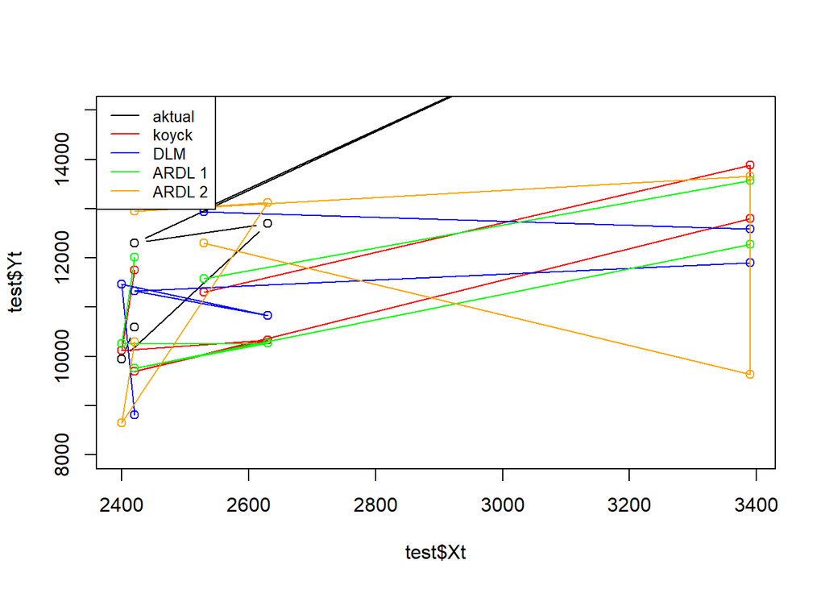

```r
par(mfrow=c(1,1))
plot(test$Xt, test$Yt, type="b", col="black", ylim=c(8000,15000))
points(test$Xt, fore.koyck$forecasts,col="red")
lines(test$Xt, fore.koyck$forecasts,col="red")
points(test$Xt, fore.dlm$forecasts,col="blue")
lines(test$Xt, fore.dlm$forecasts,col="blue")
points(test$Xt, fore.ardl$forecasts,col="green")
lines(test$Xt, fore.ardl$forecasts,col="green")
points(test$Xt, fore.ardl.op2$forecasts,col="orange")
lines(test$Xt, fore.ardl.op2$forecasts,col="orange")

legend("topleft",c("aktual", "koyck","DLM","ARDL 1", "ARDL 2"), lty=1, col=c("black","red","blue","green","orange"), cex=0.8)
```

Berdasarkan plot tersebut, terlihat bahwa plot yang paling mendekati data aktualnya adalah Model ARDL 2, sehingga dapat disimpulkan model terbaik dalam hal ini adalah model regresi ARDL 2.